# Pokemon Analysis

Tugce Kaynak

02 08 2019

KAYNAK : https://www.kaggle.com/alopez247/pokemon/downloads/pokemon.zip/2

## Veri Açıklaması:

### Pokemon Nedir?

```
Pokémon, kendi dünyasında yaşayan hayali hayvan benzeri canavarlardır. Pokémon
birbirleriyle kavga etmek gibi huyları vardır. Genellikle (insan) eğitmenlerinin emirlerine göre kavga ederler.
```

- Şimdi veri kümesinin 23 sütununu inceleyelim.
- İlk ikisi, Pokémon’un benzersiz tanımlayıcıları
- 21 değişkeninden 12’si sayısal (10 sürekli ve 2 ayrık), 6 kategorik ve 3’dür.

### Değişken incelemesi:

**Number :** Uniq değer

**Name :** Uniq değer

**Type-1 :** pokemonun fiziksel özelliği

**Type-2 :** pokemonun yeteneği (boş değerler var)

**Total :** Pokémon’un tüm temel savaş istatistiklerinin toplamı. Kendisinden sonra gelen 6 değişkenin toplamı

HP.

Attack.

Defense.

Sp_Atk.

Sp_Def.

Speed.

Bu altı değişken savaş istatistikleri ile ilgilidir. Biz Totali kullanacağız.

**Generation :**Pokémon’un serbest bırakıldığı nesil. 1 ile 6 arasında bir tam sayıdır, sayısal ayrık değişken.

**isLegendary.:** Pokémon’un efsanevi olup olmadığını belirten Boolean. Karşılaşılması ve yakalanması gerçekten zor.

**Color:** pokemon renkleri 10 gruptur. Black, Blue, Brown, Green, Grey, Pink, Purple, Red, White, ve Yellow.

**hasGender.:** booleandır. male or female. pokemonun cinsiyetini belirtir.

**Pr_Male. :** pokemonun doğada erkek yada kadın olarak görülme olasılığı

**Egg_Group_1. :** 15 gruptan oluşur. Yumurtanın özellikleridir. Amorf, Böcek, Aynen, Ejderha, Peri, Tarla, Uçan, Çimen, İnsan Gibi, Mineral, Canavar, Keşfedilmemiş, Su_1, Su_2 ve Su_3.

**Egg_Group_2. :** Pokémon türlerinde olduğu gibi, Pokémon da iki yumurta grubuna ait olabilir. iki gruba ait ise ikinci grubu bu sütunda.

**hasMegaEvolution.:** Bir Pokémon’un mega evrimleşip evrimleşmeyeceğini gösteren Boolean.

**Height_m. :** Sürekli değişken. Boy.

**Weight_kg. :** Sürekli değişken. Ağırlık.

**Catch_Rate. :** Yakalama oranı. 3 ile 255 arasında sınırlandırılmıştır. Sürekli.

**Body_Style. :** Pokémon’un vücut stili. 14 vücut stili kategorisi belirlenmiştir

### Import Data

```r
library(readr)
pokemon <- read_csv("pokemon_alopez247.csv")
knitr::kable(head(pokemon, 20))
```

| Number | Name | Type_1 | Type_2 | Total | HP | Attack | Defense | Sp_Atk | Sp_Def | Speed | Generation | isLegendary | Color | hasGender | Pr_Male | Egg_Group_1 | Egg_Group_2 | hasMegaEvolution | Height_m | Weight_kg | Catch_Rate | Body_Style |
| --- | --- | --- | --- | --- | --- | --- | --- | --- | --- | --- | --- | --- | --- | --- | --- | --- | --- | --- | --- | --- | --- | --- |
| 1 | Bulbasaur | Grass | Poison | 318 | 45 | 49 | 49 | 65 | 65 | 45 | 1 | FALSE | Green | TRUE | 0.875 | Monster | Grass | FALSE | 0.71 | 6.9 | 45 | quadruped |
| 2 | Ivysaur | Grass | Poison | 405 | 60 | 62 | 63 | 80 | 80 | 60 | 1 | FALSE | Green | TRUE | 0.875 | Monster | Grass | FALSE | 0.99 | 13.0 | 45 | quadruped |
| 3 | Venusaur | Grass | Poison | 525 | 80 | 82 | 83 | 100 | 100 | 80 | 1 | FALSE | Green | TRUE | 0.875 | Monster | Grass | TRUE | 2.01 | 100.0 | 45 | quadruped |
| 4 | Charmander | Fire | NA | 309 | 39 | 52 | 43 | 60 | 50 | 65 | 1 | FALSE | Red | TRUE | 0.875 | Monster | Dragon | FALSE | 0.61 | 8.5 | 45 | bipedal_tailed |
| 5 | Charmeleon | Fire | NA | 405 | 58 | 64 | 58 | 80 | 65 | 80 | 1 | FALSE | Red | TRUE | 0.875 | Monster | Dragon | FALSE | 1.09 | 19.0 | 45 | bipedal_tailed |
| 6 | Charizard | Fire | Flying | 534 | 78 | 84 | 78 | 109 | 85 | 100 | 1 | FALSE | Red | TRUE | 0.875 | Monster | Dragon | TRUE | 1.70 | 90.5 | 45 | bipedal_tailed |
| 7 | Squirtle | Water | NA | 314 | 44 | 48 | 65 | 50 | 64 | 43 | 1 | FALSE | Blue | TRUE | 0.875 | Monster | Water_1 | FALSE | 0.51 | 9.0 | 45 | bipedal_tailed |
| 8 | Wartortle | Water | NA | 405 | 59 | 63 | 80 | 65 | 80 | 58 | 1 | FALSE | Blue | TRUE | 0.875 | Monster | Water_1 | FALSE | 0.99 | 22.5 | 45 | bipedal_tailed |
| 9 | Blastoise | Water | NA | 530 | 79 | 83 | 100 | 85 | 105 | 78 | 1 | FALSE | Blue | TRUE | 0.875 | Monster | Water_1 | TRUE | 1.60 | 85.5 | 45 | bipedal_tailed |
| 10 | Caterpie | Bug | NA | 195 | 45 | 30 | 35 | 20 | 20 | 45 | 1 | FALSE | Green | TRUE | 0.500 | Bug | NA | FALSE | 0.30 | 2.9 | 255 | insectoid |
| 11 | Metapod | Bug | NA | 205 | 50 | 20 | 55 | 25 | 25 | 30 | 1 | FALSE | Green | TRUE | 0.500 | Bug | NA | FALSE | 0.71 | 9.9 | 120 | serpentine_body |
| 12 | Butterfree | Bug | Flying | 395 | 60 | 45 | 50 | 90 | 80 | 70 | 1 | FALSE | White | TRUE | 0.500 | Bug | NA | FALSE | 1.09 | 32.0 | 45 | four_wings |
| 13 | Weedle | Bug | Poison | 195 | 40 | 35 | 30 | 20 | 20 | 50 | 1 | FALSE | Brown | TRUE | 0.500 | Bug | NA | FALSE | 0.30 | 3.2 | 255 | serpentine_body |
| 14 | Kakuna | Bug | Poison | 205 | 45 | 25 | 50 | 25 | 25 | 35 | 1 | FALSE | Yellow | TRUE | 0.500 | Bug | NA | FALSE | 0.61 | 10.0 | 120 | serpentine_body |
| 15 | Beedrill | Bug | Poison | 395 | 65 | 90 | 40 | 45 | 80 | 75 | 1 | FALSE | Yellow | TRUE | 0.500 | Bug | NA | TRUE | 0.99 | 29.5 | 45 | four_wings |
| 16 | Pidgey | Normal | Flying | 251 | 40 | 45 | 40 | 35 | 35 | 56 | 1 | FALSE | Brown | TRUE | 0.500 | Flying | NA | FALSE | 0.30 | 1.8 | 255 | two_wings |
| 17 | Pidgeotto | Normal | Flying | 349 | 63 | 60 | 55 | 50 | 50 | 71 | 1 | FALSE | Brown | TRUE | 0.500 | Flying | NA | FALSE | 1.09 | 30.0 | 120 | two_wings |
| 18 | Pidgeot | Normal | Flying | 479 | 83 | 80 | 75 | 70 | 70 | 101 | 1 | FALSE | Brown | TRUE | 0.500 | Flying | NA | TRUE | 1.50 | 39.5 | 45 | two_wings |
| 19 | Rattata | Normal | NA | 253 | 30 | 56 | 35 | 25 | 35 | 72 | 1 | FALSE | Purple | TRUE | 0.500 | Field | NA | FALSE | 0.30 | 3.5 | 255 | quadruped |
| 20 | Raticate | Normal | NA | 413 | 55 | 81 | 60 | 50 | 70 | 97 | 1 | FALSE | Brown | TRUE | 0.500 | Field | NA | FALSE | 0.71 | 18.5 | 127 | quadruped |

```r
colnames(pokemon)
```

```
##  [1] "Number"           "Name"             "Type_1"
##  [4] "Type_2"           "Total"            "HP"
##  [7] "Attack"           "Defense"          "Sp_Atk"
## [10] "Sp_Def"           "Speed"            "Generation"
## [13] "isLegendary"      "Color"            "hasGender"
## [16] "Pr_Male"          "Egg_Group_1"      "Egg_Group_2"
## [19] "hasMegaEvolution" "Height_m"         "Weight_kg"
## [22] "Catch_Rate"       "Body_Style"
```

Data da 6 sürekli değişkenden hesaplanmış Total değişkeni Savaş gücü istatistiğini göstermektedir. Ben bu değişkeni kullanıp diğer değişkenleri datadan çıkartmak istiyorum.

```r
library(dplyr)
library(magrittr)
pokemon <- as.data.frame(pokemon)
pokemon <- select(pokemon, -c("HP", "Attack", "Defense", "Sp_Atk", "Sp_Def", "Speed"))
knitr::kable(head(pokemon, 20))
```

| Number | Name | Type_1 | Type_2 | Total | Generation | isLegendary | Color | hasGender | Pr_Male | Egg_Group_1 | Egg_Group_2 | hasMegaEvolution | Height_m | Weight_kg | Catch_Rate | Body_Style |
| --- | --- | --- | --- | --- | --- | --- | --- | --- | --- | --- | --- | --- | --- | --- | --- | --- |
| 1 | Bulbasaur | Grass | Poison | 318 | 1 | FALSE | Green | TRUE | 0.875 | Monster | Grass | FALSE | 0.71 | 6.9 | 45 | quadruped |
| 2 | Ivysaur | Grass | Poison | 405 | 1 | FALSE | Green | TRUE | 0.875 | Monster | Grass | FALSE | 0.99 | 13.0 | 45 | quadruped |
| 3 | Venusaur | Grass | Poison | 525 | 1 | FALSE | Green | TRUE | 0.875 | Monster | Grass | TRUE | 2.01 | 100.0 | 45 | quadruped |
| 4 | Charmander | Fire | NA | 309 | 1 | FALSE | Red | TRUE | 0.875 | Monster | Dragon | FALSE | 0.61 | 8.5 | 45 | bipedal_tailed |
| 5 | Charmeleon | Fire | NA | 405 | 1 | FALSE | Red | TRUE | 0.875 | Monster | Dragon | FALSE | 1.09 | 19.0 | 45 | bipedal_tailed |
| 6 | Charizard | Fire | Flying | 534 | 1 | FALSE | Red | TRUE | 0.875 | Monster | Dragon | TRUE | 1.70 | 90.5 | 45 | bipedal_tailed |
| 7 | Squirtle | Water | NA | 314 | 1 | FALSE | Blue | TRUE | 0.875 | Monster | Water_1 | FALSE | 0.51 | 9.0 | 45 | bipedal_tailed |
| 8 | Wartortle | Water | NA | 405 | 1 | FALSE | Blue | TRUE | 0.875 | Monster | Water_1 | FALSE | 0.99 | 22.5 | 45 | bipedal_tailed |
| 9 | Blastoise | Water | NA | 530 | 1 | FALSE | Blue | TRUE | 0.875 | Monster | Water_1 | TRUE | 1.60 | 85.5 | 45 | bipedal_tailed |
| 10 | Caterpie | Bug | NA | 195 | 1 | FALSE | Green | TRUE | 0.500 | Bug | NA | FALSE | 0.30 | 2.9 | 255 | insectoid |
| 11 | Metapod | Bug | NA | 205 | 1 | FALSE | Green | TRUE | 0.500 | Bug | NA | FALSE | 0.71 | 9.9 | 120 | serpentine_body |
| 12 | Butterfree | Bug | Flying | 395 | 1 | FALSE | White | TRUE | 0.500 | Bug | NA | FALSE | 1.09 | 32.0 | 45 | four_wings |
| 13 | Weedle | Bug | Poison | 195 | 1 | FALSE | Brown | TRUE | 0.500 | Bug | NA | FALSE | 0.30 | 3.2 | 255 | serpentine_body |
| 14 | Kakuna | Bug | Poison | 205 | 1 | FALSE | Yellow | TRUE | 0.500 | Bug | NA | FALSE | 0.61 | 10.0 | 120 | serpentine_body |
| 15 | Beedrill | Bug | Poison | 395 | 1 | FALSE | Yellow | TRUE | 0.500 | Bug | NA | TRUE | 0.99 | 29.5 | 45 | four_wings |
| 16 | Pidgey | Normal | Flying | 251 | 1 | FALSE | Brown | TRUE | 0.500 | Flying | NA | FALSE | 0.30 | 1.8 | 255 | two_wings |
| 17 | Pidgeotto | Normal | Flying | 349 | 1 | FALSE | Brown | TRUE | 0.500 | Flying | NA | FALSE | 1.09 | 30.0 | 120 | two_wings |
| 18 | Pidgeot | Normal | Flying | 479 | 1 | FALSE | Brown | TRUE | 0.500 | Flying | NA | TRUE | 1.50 | 39.5 | 45 | two_wings |
| 19 | Rattata | Normal | NA | 253 | 1 | FALSE | Purple | TRUE | 0.500 | Field | NA | FALSE | 0.30 | 3.5 | 255 | quadruped |
| 20 | Raticate | Normal | NA | 413 | 1 | FALSE | Brown | TRUE | 0.500 | Field | NA | FALSE | 0.71 | 18.5 | 127 | quadruped |

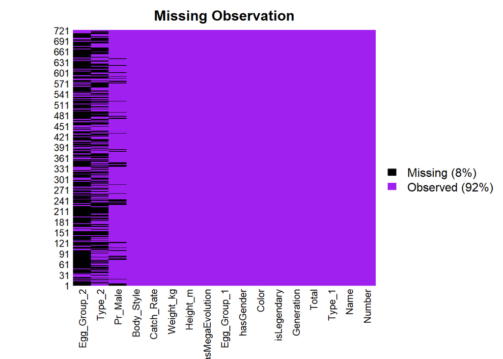

```r
library(Amelia)
missmap(pokemon, main = "Missing Observation", col = c("black", "purple"))
```

Yaptığımız bu analizde datadaki 3 değişkende boş gözlem değerleri olduğu görülmektedir. Bu değişkenleri de datamızdan çıkaralım.

```r
pokemon <- select(pokemon, -c("Egg_Group_2", "Type_2", "Pr_Male" ))
knitr::kable(head(pokemon, 20))
```

| Number | Name | Type_1 | Total | Generation | isLegendary | Color | hasGender | Egg_Group_1 | hasMegaEvolution | Height_m | Weight_kg | Catch_Rate | Body_Style |
| --- | --- | --- | --- | --- | --- | --- | --- | --- | --- | --- | --- | --- | --- |
| 1 | Bulbasaur | Grass | 318 | 1 | FALSE | Green | TRUE | Monster | FALSE | 0.71 | 6.9 | 45 | quadruped |
| 2 | Ivysaur | Grass | 405 | 1 | FALSE | Green | TRUE | Monster | FALSE | 0.99 | 13.0 | 45 | quadruped |
| 3 | Venusaur | Grass | 525 | 1 | FALSE | Green | TRUE | Monster | TRUE | 2.01 | 100.0 | 45 | quadruped |
| 4 | Charmander | Fire | 309 | 1 | FALSE | Red | TRUE | Monster | FALSE | 0.61 | 8.5 | 45 | bipedal_tailed |
| 5 | Charmeleon | Fire | 405 | 1 | FALSE | Red | TRUE | Monster | FALSE | 1.09 | 19.0 | 45 | bipedal_tailed |
| 6 | Charizard | Fire | 534 | 1 | FALSE | Red | TRUE | Monster | TRUE | 1.70 | 90.5 | 45 | bipedal_tailed |
| 7 | Squirtle | Water | 314 | 1 | FALSE | Blue | TRUE | Monster | FALSE | 0.51 | 9.0 | 45 | bipedal_tailed |
| 8 | Wartortle | Water | 405 | 1 | FALSE | Blue | TRUE | Monster | FALSE | 0.99 | 22.5 | 45 | bipedal_tailed |
| 9 | Blastoise | Water | 530 | 1 | FALSE | Blue | TRUE | Monster | TRUE | 1.60 | 85.5 | 45 | bipedal_tailed |
| 10 | Caterpie | Bug | 195 | 1 | FALSE | Green | TRUE | Bug | FALSE | 0.30 | 2.9 | 255 | insectoid |
| 11 | Metapod | Bug | 205 | 1 | FALSE | Green | TRUE | Bug | FALSE | 0.71 | 9.9 | 120 | serpentine_body |
| 12 | Butterfree | Bug | 395 | 1 | FALSE | White | TRUE | Bug | FALSE | 1.09 | 32.0 | 45 | four_wings |
| 13 | Weedle | Bug | 195 | 1 | FALSE | Brown | TRUE | Bug | FALSE | 0.30 | 3.2 | 255 | serpentine_body |
| 14 | Kakuna | Bug | 205 | 1 | FALSE | Yellow | TRUE | Bug | FALSE | 0.61 | 10.0 | 120 | serpentine_body |
| 15 | Beedrill | Bug | 395 | 1 | FALSE | Yellow | TRUE | Bug | TRUE | 0.99 | 29.5 | 45 | four_wings |
| 16 | Pidgey | Normal | 251 | 1 | FALSE | Brown | TRUE | Flying | FALSE | 0.30 | 1.8 | 255 | two_wings |
| 17 | Pidgeotto | Normal | 349 | 1 | FALSE | Brown | TRUE | Flying | FALSE | 1.09 | 30.0 | 120 | two_wings |
| 18 | Pidgeot | Normal | 479 | 1 | FALSE | Brown | TRUE | Flying | TRUE | 1.50 | 39.5 | 45 | two_wings |
| 19 | Rattata | Normal | 253 | 1 | FALSE | Purple | TRUE | Field | FALSE | 0.30 | 3.5 | 255 | quadruped |
| 20 | Raticate | Normal | 413 | 1 | FALSE | Brown | TRUE | Field | FALSE | 0.71 | 18.5 | 127 | quadruped |

```r
summary(pokemon)
```

```
##      Number        Name              Type_1              Total
##  Min.   :  1   Length:721         Length:721         Min.   :180.0
##  1st Qu.:181   Class :character   Class :character   1st Qu.:320.0
##  Median :361   Mode  :character   Mode  :character   Median :424.0
##  Mean   :361                                         Mean   :417.9
##  3rd Qu.:541                                         3rd Qu.:499.0
##  Max.   :721                                         Max.   :720.0
##    Generation    isLegendary        Color           hasGender
##  Min.   :1.000   Mode :logical   Length:721         Mode :logical
##  1st Qu.:2.000   FALSE:675       Class :character   FALSE:77
##  Median :3.000   TRUE :46        Mode  :character   TRUE :644
##  Mean   :3.323
##  3rd Qu.:5.000
##  Max.   :6.000
##  Egg_Group_1        hasMegaEvolution    Height_m        Weight_kg
##  Length:721         Mode :logical    Min.   : 0.100   Min.   :  0.10
##  Class :character   FALSE:675        1st Qu.: 0.610   1st Qu.:  9.40
##  Mode  :character   TRUE :46         Median : 0.990   Median : 28.00
##                                      Mean   : 1.145   Mean   : 56.77
##                                      3rd Qu.: 1.400   3rd Qu.: 61.00
##                                      Max.   :14.500   Max.   :950.00
##    Catch_Rate     Body_Style
##  Min.   :  3.0   Length:721
##  1st Qu.: 45.0   Class :character
##  Median : 65.0   Mode  :character
##  Mean   :100.2
##  3rd Qu.:180.0
##  Max.   :255.0
```

Kalan Değişkenlerimin özet istatistikleri yukarıdaki gibidir.

```r
attach(pokemon)

Type_1 <- factor("Type_1")
Color <- factor("Color")
Egg_Group_1 <- factor("Egg_Group_1")
Body_Style  <- factor("Body_Style")

detach(pokemon)
```

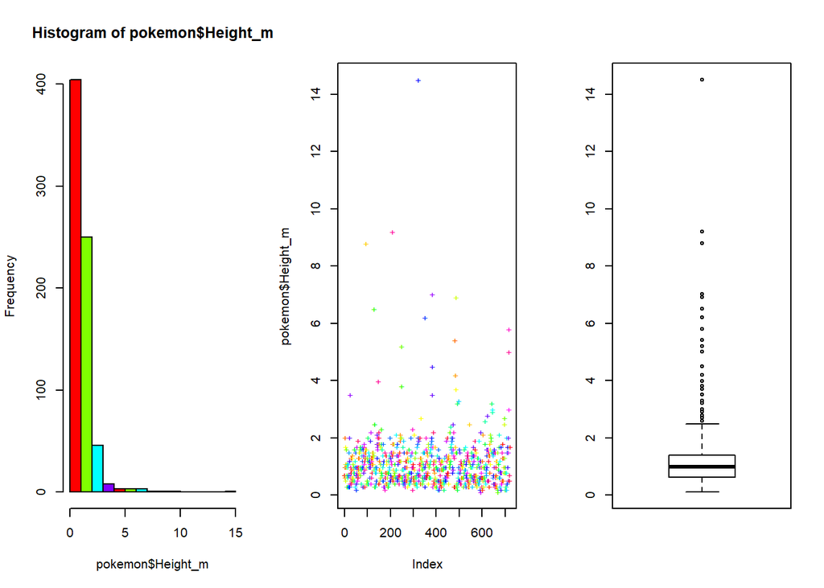

```r
par(mfrow=c(1,3))

hist(pokemon$Height_m, col = rainbow(4:8))
sunflowerplot(pokemon$Height_m, pch = "+", col = rainbow(30))
boxplot(pokemon$Height_m)
```

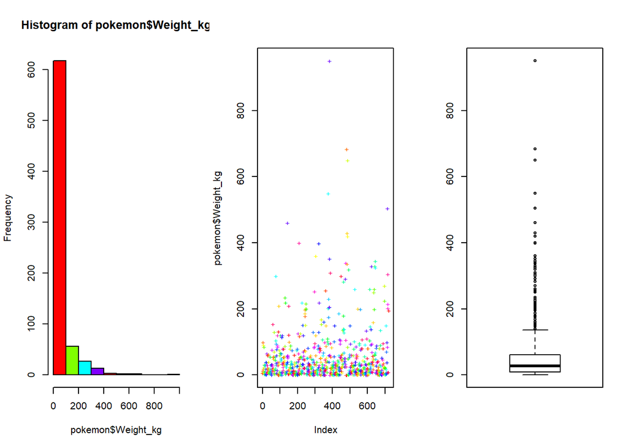

```r
par(mfrow=c(1,3))

hist(pokemon$Weight_kg, col = rainbow(4:8))
sunflowerplot(pokemon$Weight_kg, pch = "+", col = rainbow(30))
boxplot(pokemon$Weight_kg)
```

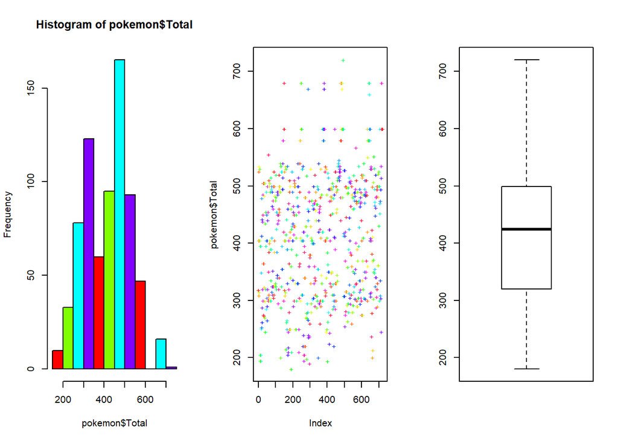

```r
par(mfrow=c(1,3))

hist(pokemon$Total, col = rainbow(4:8))
sunflowerplot(pokemon$Total, pch = "+", col = rainbow(30))
boxplot(pokemon$Total)
```

## NORMALLİK TESTİ

```r
shapiro.test(x = pokemon$Total)
```

```
##
##  Shapiro-Wilk normality test
##
## data:  pokemon$Total
## W = 0.97761, p-value = 4.701e-09
```

H0 : Total değişkeni ile Normal dağılım arasında fark yoktur.

H1 : Total değişkeni ile Normal dağılım arasında fark vardır.

test sonucuna baktığımızda p-value değeri 0.05 den küçük olduğu için H0 hipotezi reddedilir. Normal Dağılmıyor.

## REGRESYON

```r
lm(pokemon$Total~pokemon$Height_m+pokemon$Weight_kg) %>%
  summary()
```

```
##
## Call:
## lm(formula = pokemon$Total ~ pokemon$Height_m + pokemon$Weight_kg)
##
## Residuals:
##     Min      1Q  Median      3Q     Max
## -487.56  -65.95    6.10   65.96  234.89
##
## Coefficients:
##                    Estimate Std. Error t value Pr(>|t|)
## (Intercept)       357.81915    4.94731  72.326  < 2e-16 ***
## pokemon$Height_m   32.16746    4.24413   7.579 1.07e-13 ***
## pokemon$Weight_kg   0.41033    0.04975   8.248 7.68e-16 ***
## ---
## Signif. codes:  0 '***' 0.001 '**' 0.01 '*' 0.05 '.' 0.1 ' ' 1
##
## Residual standard error: 89.21 on 718 degrees of freedom
## Multiple R-squared:  0.3401, Adjusted R-squared:  0.3382
## F-statistic:   185 on 2 and 718 DF,  p-value: < 2.2e-16
```

### Model Geliştirme

```r
lm(pokemon$Total~pokemon$Height_m+pokemon$Weight_kg+pokemon$hasGender) %>%
  summary()
```

```
##
## Call:
## lm(formula = pokemon$Total ~ pokemon$Height_m + pokemon$Weight_kg +
##     pokemon$hasGender)
##
## Residuals:
##     Min      1Q  Median      3Q     Max
## -461.24  -63.27    7.05   68.80  210.13
##
## Coefficients:
##                        Estimate Std. Error t value Pr(>|t|)
## (Intercept)           437.23676   11.60089  37.690  < 2e-16 ***
## pokemon$Height_m       33.88363    4.09572   8.273 6.36e-16 ***
## pokemon$Weight_kg       0.29219    0.05045   5.792 1.04e-08 ***
## pokemon$hasGenderTRUE -83.60422   11.13382  -7.509 1.77e-13 ***
## ---
## Signif. codes:  0 '***' 0.001 '**' 0.01 '*' 0.05 '.' 0.1 ' ' 1
##
## Residual standard error: 85.96 on 717 degrees of freedom
## Multiple R-squared:  0.3882, Adjusted R-squared:  0.3856
## F-statistic: 151.6 on 3 and 717 DF,  p-value: < 2.2e-16
```

```r
lm(pokemon$Total~pokemon$Height_m+pokemon$Weight_kg+pokemon$hasGender+pokemon$Color) %>%
  summary()
```

```
##
## Call:
## lm(formula = pokemon$Total ~ pokemon$Height_m + pokemon$Weight_kg +
##     pokemon$hasGender + pokemon$Color)
##
## Residuals:
##     Min      1Q  Median      3Q     Max
## -459.26  -62.83    7.85   68.81  220.69
##
## Coefficients:
##                        Estimate Std. Error t value Pr(>|t|)
## (Intercept)           436.04142   18.80105  23.192  < 2e-16 ***
## pokemon$Height_m       33.34213    4.11692   8.099 2.43e-15 ***
## pokemon$Weight_kg       0.30704    0.05111   6.008 3.01e-09 ***
## pokemon$hasGenderTRUE -81.70138   11.20085  -7.294 8.07e-13 ***
## pokemon$ColorBlue      -0.74205   16.94011  -0.044    0.965
## pokemon$ColorBrown    -12.11349   17.31973  -0.699    0.485
## pokemon$ColorGreen      1.54855   18.05059   0.086    0.932
## pokemon$ColorGrey     -11.35188   18.41099  -0.617    0.538
## pokemon$ColorPink      -6.40724   20.35615  -0.315    0.753
## pokemon$ColorPurple     9.60279   18.61658   0.516    0.606
## pokemon$ColorRed        0.74121   18.16962   0.041    0.967
## pokemon$ColorWhite     -2.36711   19.33947  -0.122    0.903
## pokemon$ColorYellow    19.91276   18.67981   1.066    0.287
## ---
## Signif. codes:  0 '***' 0.001 '**' 0.01 '*' 0.05 '.' 0.1 ' ' 1
##
## Residual standard error: 86.03 on 708 degrees of freedom
## Multiple R-squared:  0.3948, Adjusted R-squared:  0.3846
## F-statistic: 38.49 on 12 and 708 DF,  p-value: < 2.2e-16
```

modele renk değişkeni eklendiğinde renk değişkeninin tüm gurupları için bağımlı değişkeni açıklamakta anlamsız olduğunu görüyoruz. yani pokemonun renginin kazanma gücü istatistiğine etkisi yoktur. bu değişkeni çıkartıyorum

```r
lm(pokemon$Total~pokemon$Height_m+pokemon$Weight_kg+pokemon$hasGender+pokemon$Catch_Rate) %>%
  summary()
```

```
##
## Call:
## lm(formula = pokemon$Total ~ pokemon$Height_m + pokemon$Weight_kg +
##     pokemon$hasGender + pokemon$Catch_Rate)
##
## Residuals:
##     Min      1Q  Median      3Q     Max
## -255.82  -35.75    5.76   42.14  184.36
##
## Coefficients:
##                        Estimate Std. Error t value Pr(>|t|)
## (Intercept)           511.91141    9.27774  55.176  < 2e-16 ***
## pokemon$Height_m       18.15596    3.14966   5.764 1.22e-08 ***
## pokemon$Weight_kg       0.19748    0.03813   5.179 2.90e-07 ***
## pokemon$hasGenderTRUE -48.46342    8.49926  -5.702 1.73e-08 ***
## pokemon$Catch_Rate     -0.82474    0.03505 -23.529  < 2e-16 ***
## ---
## Signif. codes:  0 '***' 0.001 '**' 0.01 '*' 0.05 '.' 0.1 ' ' 1
##
## Residual standard error: 64.6 on 716 degrees of freedom
## Multiple R-squared:  0.655,  Adjusted R-squared:  0.653
## F-statistic: 339.8 on 4 and 716 DF,  p-value: < 2.2e-16
```

```r
lm(pokemon$Total~pokemon$Height_m+pokemon$Weight_kg+pokemon$hasGender+pokemon$hasMegaEvolution) %>%
  summary()
```

```
##
## Call:
## lm(formula = pokemon$Total ~ pokemon$Height_m + pokemon$Weight_kg +
##     pokemon$hasGender + pokemon$hasMegaEvolution)
##
## Residuals:
##     Min      1Q  Median      3Q     Max
## -416.51  -61.30    9.53   69.29  217.49
##
## Coefficients:
##                               Estimate Std. Error t value Pr(>|t|)
## (Intercept)                  439.63005   11.42639  38.475  < 2e-16 ***
## pokemon$Height_m              30.99400    4.07272   7.610 8.65e-14 ***
## pokemon$Weight_kg              0.28740    0.04966   5.788 1.07e-08 ***
## pokemon$hasGenderTRUE        -86.91989   10.97703  -7.918 9.18e-15 ***
## pokemon$hasMegaEvolutionTRUE  65.03183   13.16574   4.939 9.76e-07 ***
## ---
## Signif. codes:  0 '***' 0.001 '**' 0.01 '*' 0.05 '.' 0.1 ' ' 1
##
## Residual standard error: 84.59 on 716 degrees of freedom
## Multiple R-squared:  0.4083, Adjusted R-squared:  0.405
## F-statistic: 123.5 on 4 and 716 DF,  p-value: < 2.2e-16
```

### VARYANS HOMOJENLİĞİ

```r
library(car)
leveneTest(pokemon$Total~pokemon$Color)
```

```
## Levene's Test for Homogeneity of Variance (center = median)
##        Df F value Pr(>F)
## group   9  0.2643 0.9838
##       711
```

Ho: homjendir.

H1: homojen değildir.

Ho reddedilemez.

### ANOVA

```r
oneway.test(pokemon$Total~pokemon$Color, var.equal = T)
```

```
##
##  One-way analysis of means
##
## data:  pokemon$Total and pokemon$Color
## F = 0.74226, num df = 9, denom df = 711, p-value = 0.6702
```

Ho: Renk Grupları arasında anlamlı bir fark yoktur.

H1: Vardır.

Ho reddedilemez. renk grupları arasında savaş kazanma istatistiği bakımından bir fark yoktur.

```r
leveneTest(pokemon$Total~pokemon$isLegendary)
```

```
## Levene's Test for Homogeneity of Variance (center = median)
##        Df F value    Pr(>F)
## group   1  45.676 2.885e-11 ***
##       719
## ---
## Signif. codes:  0 '***' 0.001 '**' 0.01 '*' 0.05 '.' 0.1 ' ' 1
```

Varyanslar eşit değil.

```r
oneway.test(pokemon$Total~pokemon$isLegendary, var.equal = F)
```

```
##
##  One-way analysis of means (not assuming equal variances)
##
## data:  pokemon$Total and pokemon$isLegendary
## F = 799.02, num df = 1.000, denom df = 78.739, p-value < 2.2e-16
```

pokemonun efsanevi olup olmadığını gösteren logical değişkenin iki grubu arasında çok büyük bir fark vardır.

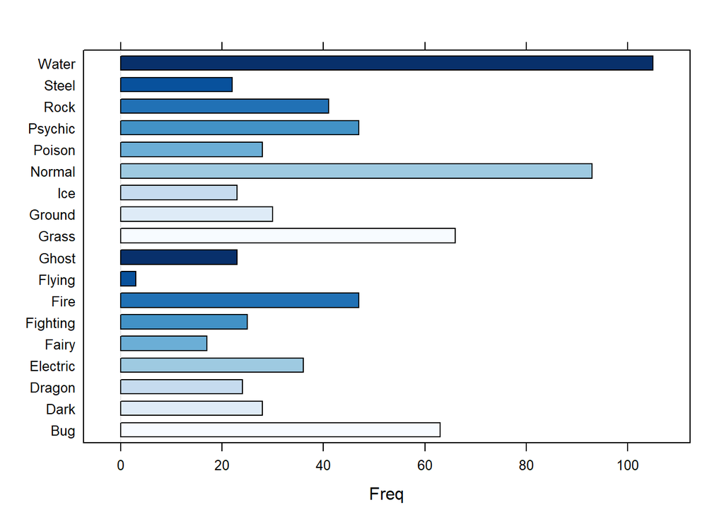

```r
library(lattice)
barchart(pokemon$Type_1, col = blues9)
```

```r
rownames(pokemon) <- pokemon$Name
View(pokemon)
```

```r
table(as.character(pokemon$Type_1)) %>%
knitr::kable()
```

| Var1 | Freq |
| --- | --- |
| Bug | 63 |
| Dark | 28 |
| Dragon | 24 |
| Electric | 36 |
| Fairy | 17 |
| Fighting | 25 |
| Fire | 47 |
| Flying | 3 |
| Ghost | 23 |
| Grass | 66 |
| Ground | 30 |
| Ice | 23 |
| Normal | 93 |
| Poison | 28 |
| Psychic | 47 |
| Rock | 41 |
| Steel | 22 |
| Water | 105 |

[figure not shown]

```r
library(grDevices)
a <- filter(pokemon, (pokemon$Type_1 == "Electric"))
stars(a, key.loc = c(19, 2), draw.segments = TRUE, labels = a$Name)
```

[figure not shown]

```r
a <- filter(pokemon, (pokemon$Type_1 == "Water"))
stars(a, key.loc = c(30, 2), draw.segments = TRUE, labels = a$Name)
```

[figure not shown]

```r
a <- filter(pokemon, (pokemon$Type_1 == "Psychic"))
stars(a, key.loc = c(20, 2), draw.segments = TRUE, labels = a$Name)
```

[figure not shown]

```r
a <- filter(pokemon, (pokemon$Type_1 == "Flying"))
stars(a, key.loc = c(20, 2), draw.segments = TRUE, labels = a$Name)
```